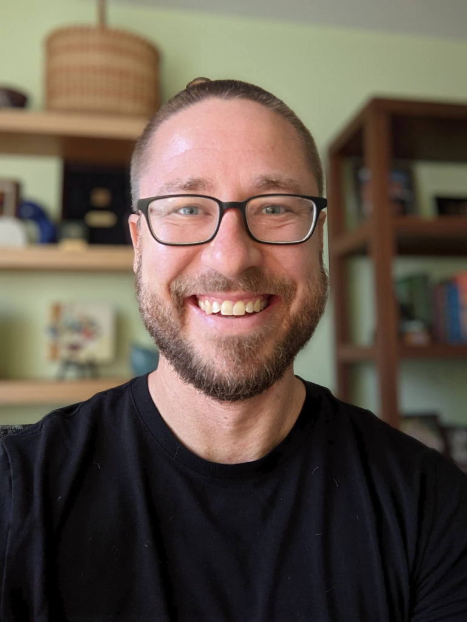

# Jeff Leek

## Bio

Jeff is J Orin Edson Foundation Chair of Biostatistics at the [Fred Hutchinson Cancer Center](https://www.fredhutch.org/) and co-founder and CEO at [Synthesize Bio](https://www.synthesize.bio/). The theme of Jeff’s work is to “build things to help people”. Currently his major areas of focus are:

- [Synthesize Bio](https://www.synthesize.bio/) | The generative genomics company building AI models to perform biomedical experiments.
- The [Cancer AI Alliance](https://www.canceralliance.ai/) | a national alliance to build a federated AI cancer laboratory
- [A Fred Hutch research group](https://www.fredhutch.org/en/faculty-lab-directory/leek-jeff.html) | Focused on biomedical data science and AI

Some of his past projects are:

- The [Fred Hutch Data Science Lab](https://hutchdatascience.org/)/[Fred Hutch Office of the Chief Data Officer](https://ocdo.fredhutch.org/) | The Data Office function supporting the data ecosystem at Fred Hutch
- [The JHU Data Science Specialization](https://www.coursera.org/specializations/jhu-data-science/) | Massive online open courses that have taught more than 10 million people data science and AI skills
- [Datatrail](https://magazine.jhsph.edu/2019/data-science-careers-baltimores-underserved-community-members) | A community-based data science education for economic and public health development.
- [The Genomic Data Science Community Network](http://www.gdscn.org/) | A faculty network to [expand access to genomic data science
- [The ITCR Training Network](https://www.itcrtraining.org/) | A training network to help people learn to use cancer informatics tools
- [Blackbird Laboratories](https://blackbirdlab.org/) | Next generation life science accelerator in Baltimore
- [swirl](https://swirlstats.com/) | Software to learn R in R

He is a Fellow of the American Statistical Association and a recipient of the [Mortimer Spiegelman Award](https://spiegelmanaward.github.io/), [Committee of Presidents of Statistical Societies Presidential Award](https://en.wikipedia.org/wiki/COPSS_Presidents%27_Award) and was named to the [Time AI 100](https://time.com/collections/time100-ai-2025/7305795/jeff-leek/).

## Products

These are products of our various efforts to help people make sense of biomedical data.

**[Talks](https://jtleek.com/talks)** | Talks about our work

**[Papers](https://scholar.google.com/citations?user=HI-I6C0AAAAJ&hl=en&oi=ao)** | Papers about our work

**[Software](https://github.com/jtleek/software)** | Software we’ve made

**[Data](https://github.com/jtleek/data)** | Data resources we’ve built

**[Books](https://github.com/jtleek/books)** | Books I’ve written

**[Guides](https://github.com/search?q=user%3Ajtleek+guides)** | Guides I’ve written

**[Courses](https://github.com/jtleek/courses)** | Courses I’ve taught

**[Blog](https://simplystatistics.org/)** | Blog I help write